## Background and Model

This application was created for the [Coursera Data Science Specialization Capstone](https://www.coursera.org/learn/data-science-project/home/info).

This project involved developing a predictive model of text starting with a really large, unstructured database of the English language. In order to do this, it was necessary to clean the data while doing an exploratory analysis to understand what we were dealing with.

To be specific, all text was set to lower case, and the punctuation symbols were removed, as the numeric characters, and all the profanity words.

Later, we were tasked with building a prediction model and testing it, in pursuance of making a data product in the shape of a [Shiny Application](https://shiny.rstudio.com/)

The model used was a simple [“Backoff Model”](https://en.wikipedia.org/wiki/Katz%27s_back-off_model), which is constructed using [N-Grams](https://en.wikipedia.org/wiki/N-gram) and the Markov assumption, which in this context states that the probability of a word depends only on the previous word or sequence of words. For this project I built an unigram, bigram, trigram, and quadgram frequency dictionaries. When the user submits some text, the algorithm will take the last three words and look for them in the quadgram dictionary, if there’s a match it’ll give the prediction, otherwise, it will take last two word and search in the trigram dictionary, and so on until it reaches the unigram dictionary.

## Tests Statistics

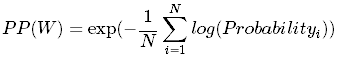

And applying it to the dictionaries gives the following values, showing that the higher the n-gram length the lower the perplexity

| Bigram | Trigram | Quadgram |
| --- | --- | --- |
| 348.42 | 8.63 | 1.81 |

For the algorithm, it’s accuracy was measured by using a random sample of 14.000 words (due to time limitations[^1]) of the test set, and calculating the proportion of correct predictions, as the model it’s design to give more than one suggestion per word there are three rows: the first one is the accuracy measure for ten suggestions, and the second one is for five suggestions, while the last row shows the statistics for only one suggestion.

|  | Bigram | Trigram | Quadgram |
| --- | --- | --- | --- |
| 10 Suggestions | 0.81 | 0.88 | 0.84 |
| 5 Suggestions | 0.74 | 0.84 | 0.80 |
| 1 Suggestion | 0.55 | 0.70 | 0.67 |

## Application

My Application has three grids:

1. Input grid (Upper-Left Corner): Where the user specifies the text which it’s next word will be predicted, and the desired number of suggestions.
2. Table grid (Upper-Right Corner): Where a table displays the predicted words and their associated probability.
3. Interactive plot grid (Bottom): Where a bar plot displays the predicted words and their associated probability.

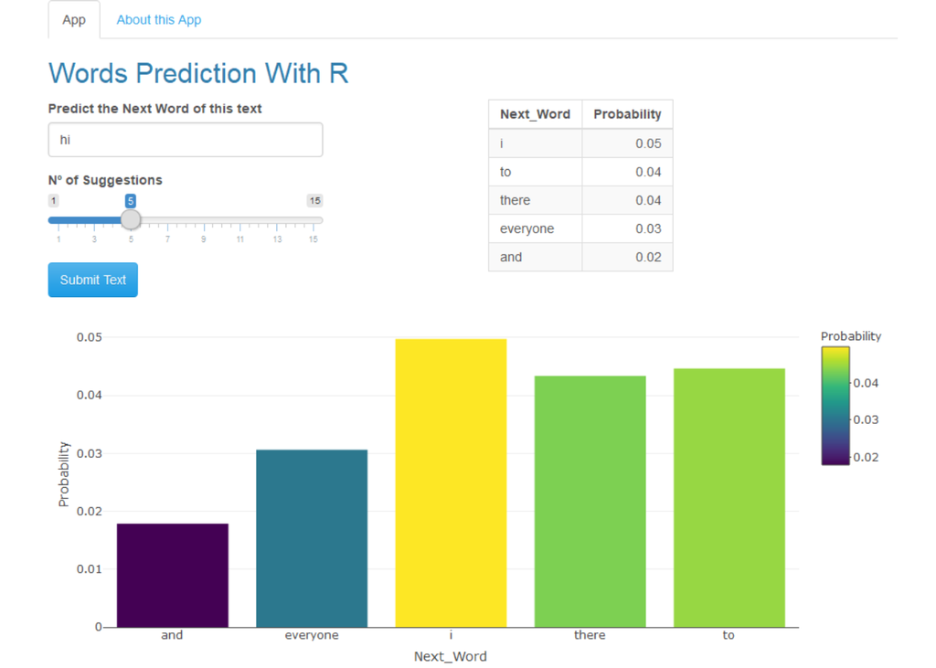

## Aditional Information

-The code used for this project can be found my [GitHub Repository](https://github.com/giunide/datascience_capstone)

-The application is hosted in this [Shinny Server](https://giunide.shinyapps.io/Data_Science_Capstone_Proyect/)

[^1]: The algorithm takes 0.3 seconds to run once, for 14.000 words it took 1 hour per dictionary.